# jekyll-jupyter-notebook20240415-1921-bubrrn

[figure not shown]

Data akselerogram sangat berguna dan dapat dimanfaatkan untuk keperluan ekstraksi simpangan tanah coseismik dari hasil integrasi dua kali akselerasi (Boore, 1999; Wu dan Wu, 2007), hanya saja karena efek histerisis, tilting, dan efek goyangan instrumen membuat adanya efek *drift* yang menyebabkan hasil tidak realistis (Chao dkk, 2010).

Pada kasus gempa Chi-Chi, teramati pergeseran/*offset* sebesar 8m dengan pengamatan GPS menunjukkan gerakan 340 cm dan 180 cm pada komponen horizonal dan vertikal (Boore, 1999; RCEP DPRI Kyoto; Academia Sinica). Pengamatan *displacement* hasil integrasi akselerasi pada TCU129 menunjukkan hasil kurang realistis yaitu 15 meter yang kemudian diduga terganggu oleh efek *baseline* sehingga perlu dilakukan koreksi atau analisis.

Pada *notebook* ini akan dilakukan lima macam analisis yang mengacu pada Boore (1999) untuk membandingkan efek berbagai koreksi terhadap *displacement*:

1. Koreksi dengan *baseline* *pre-event*
2. Koreksi dengan *fitting* *event*
3. Koreksi dengan filter akausal
4. Koreksi dengan filter kausal
5. Koreksi dengan Metode Iwan Opsi I

Data perlu diunduh secara manual atau otomatis melalui:

```python
!curl https://simpan.ugm.ac.id/s/N8DbowFH8ywgm2e/download > CWB.TCU129.Z
!curl https://simpan.ugm.ac.id/s/awgFsfM4sf3M0vw/download > CWB.TCU129.E
!curl https://simpan.ugm.ac.id/s/NHLCWCpcdHobFzq/download > CWB.TCU129.N
```

```
  % Total    % Received % Xferd  Average Speed   Time    Time     Time  Current
                                 Dload  Upload   Total   Spent    Left  Speed
100  504k  100  504k    0     0   152k      0  0:00:03  0:00:03 --:--:--  152k
  % Total    % Received % Xferd  Average Speed   Time    Time     Time  Current
                                 Dload  Upload   Total   Spent    Left  Speed
100  504k  100  504k    0     0   154k      0  0:00:03  0:00:03 --:--:--  154k
  % Total    % Received % Xferd  Average Speed   Time    Time     Time  Current
                                 Dload  Upload   Total   Spent    Left  Speed
100  504k  100  504k    0     0   167k      0  0:00:03  0:00:03 --:--:--  167k
```

## 1 Membaca Data

Data yang digunakan diunduh dari [strongmotioncenter.org](https://www.strongmotioncenter.org/vdc/scripts/event.plx?evt=629) dalam format ASCII sehingga agar bisa diproses dengan `obspy` kita akan parsing data tersebut dengan bantuan `pandas`:

### 1.1 Mendefinisikan parameter rekaman

Walaupun parameter rekaman kita dapat *parsing* otomatis tetapi pada contoh ini kita definisikan secara manual dengan melihat file data:

```python
from obspy import UTCDateTime

delta=0.005                                     # jarak sampling dalam sekon
station='TCU129'                                # nama stasiun
network='CWB'                                   # nama jaringan
starttime=UTCDateTime('19990920T17:47:15.670')  # waktu awal rekaman
```

### 1.2 Membaca data ASCII

Pembacaan data ASCII akan dilakukan menggunakan bantuan `pandas` fixed width (`pandas.fwf`) mulai dari baris 52 dengan lebar 14:

```python
from obspy import Trace, Stream
import pandas as pd

skiprow=51                # jumlah baris yang dilewati
widths=[14]               # ukuran kolom (jumlah karakter)

data_z = pd.read_fwf('/content/CWB.TCU129.Z', skiprows=51, widths=[14], names=['acc'])
data_n = pd.read_fwf('/content/CWB.TCU129.N', skiprows=51, widths=[14], names=['acc'])
data_e = pd.read_fwf('/content/CWB.TCU129.E', skiprows=51, widths=[14], names=['acc'])
data_z
```

|  | acc |
| --- | --- |
| 0 | -0.119751 |
| 1 | 0.000000 |
| 2 | -0.059875 |
| 3 | 0.000000 |
| 4 | 0.000000 |
| ... | ... |
| 31995 | -1.856140 |
| 31996 | -1.437012 |
| 31997 | -0.778381 |
| 31998 | 0.000000 |
| 31999 | 0.359253 |

32000 rows × 1 columns

### 1.3 Mengonversi data menjadi MSEED

Data akan kita simpan menjadi MSEED sebelum kemudian nanti dibaca lagi untuk mendemokan penyimpanan data dan pembuatan objek `Stream` atau `Trace` dari `obspy`. Data mula-mula akan kita ubah terlebih dahulu menjadi bentuk `numpy.array` menggunakan `Pandas.Series.to_numpy` kemudian memanfaatkan loop untuk membuat `Trace` yang kemudian disimpan dalam bentuk MSEED untuk masing-masing trace komponen ZNE:

```python
# mengubah data menjadi numpy.array
data_placeholder_fl_z = data_z['acc'].to_numpy()
data_placeholder_fl_n = data_n['acc'].to_numpy()
data_placeholder_fl_e = data_e['acc'].to_numpy()

# loop untuk membuat objek Trace dan menyimpan dalam MSEED
for data, channel in zip([data_placeholder_fl_z, data_placeholder_fl_n, data_placeholder_fl_e],['Z','N','E']):
  trace = Trace(data=data)                # mengisi trace dengan data dalam bentuk numpy.array
  trace.stats.delta=delta                 # mengisi delta pada stats
  trace.stats.starttime = starttime       # mengisi starttime
  trace.stats.network = network           # mengisi jaringan
  trace.stats.station = station           # mengisi stasiun
  trace.stats.channel = channel           # mengisi channel sesuai dengn masing-masing channel
  trace.write(f"{network}.{station}.{channel}.{str(starttime)}.mseed")  # menyimpan dalam file MSEED
```

### 1.4 Membaca data yang sudah dikonversi

Karena data sudah tersimpan dalam file explorer maka kita dapat membaca tersebut:

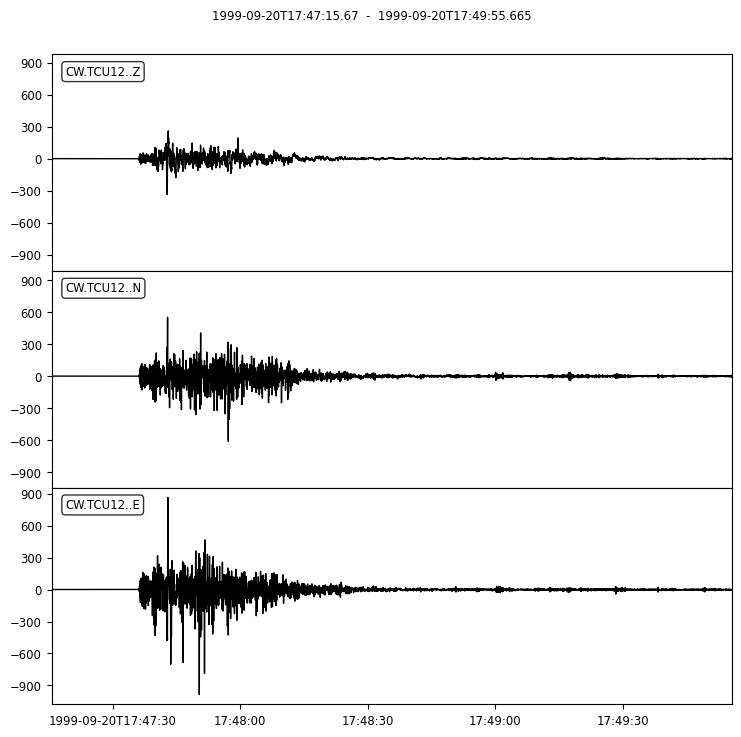

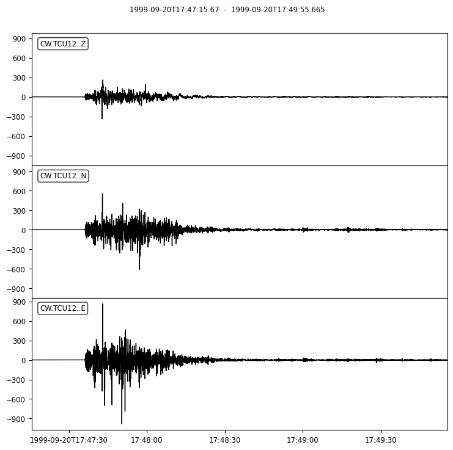

```python
from obspy import read

sta = read('/content/CWB.TCU129.Z.1999-09-20T17:47:15.670000Z.mseed')
sta += read('/content/CWB.TCU129.N.1999-09-20T17:47:15.670000Z.mseed')
sta += read('/content/CWB.TCU129.E.1999-09-20T17:47:15.670000Z.mseed')

sta.plot()
```

### 1.5 Memotong data

Agar data yang diolah sama dengan pada referensi paper maka data akan kita potong dengan hanya mengambil 90 detik pertama:

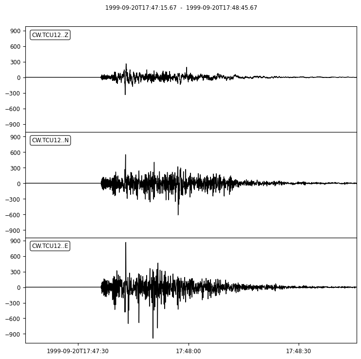

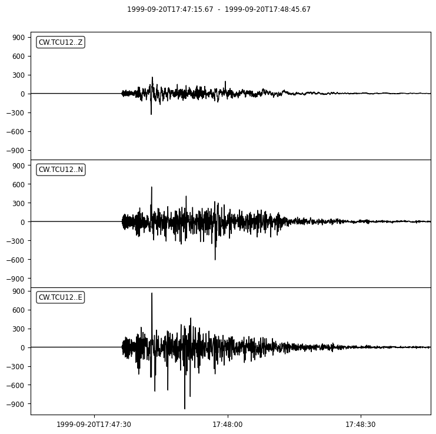

```python
starttime = sta[0].stats.starttime
endtime = starttime+90

sta.trim(starttime, endtime)
sta.plot()
```

### 1.6 Memilih komponen E

Data yang akan diolah pada contoh ini adalah untuk komponen E dahulu, kita bisa memilih komponen dengan `Stream.select`:

```python
sta_e = sta.copy()
sta_e = sta_e.select(channel='E')
print(sta_e)

sta_e.plot()
```

[output not shown]

```
1 Trace(s) in Stream:
CW.TCU12..E | 1999-09-20T17:47:15.670000Z - 1999-09-20T17:48:45.670000Z | 200.0 Hz, 18001 samples
```

## 2 Melakukan integrasi untuk mendapatkan kecepatan dan simpangan (*displacement*)

Sama seperti pada materi sebelumnya data akselerasi dapat kita integrasi menjadi kecepatan dan simpangan (*displacement*).

### 2.1 Integrasi untuk mendapatkan kecepatan

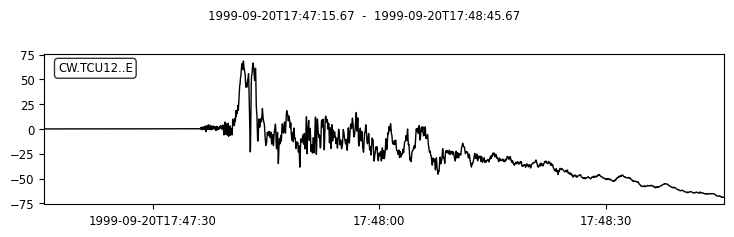

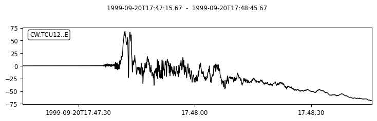

```python
stv_e = sta_e.copy()
stv_e.integrate()
stv_e.plot()
```

Pada hasil integrasi di atas terlihat adanya bentuk gelombang yang tidak realistis karena kecepatan akhir terus bertambah dan tidak menjadi nol kembali.

### 2.2 Integrasi untuk mendapatkan simpangan (*displacement*)

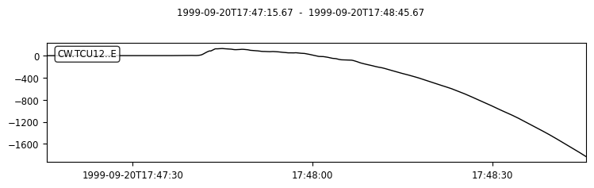

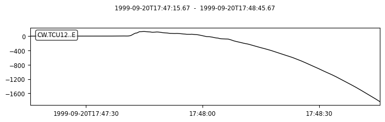

```python
std_e = stv_e.copy()
std_e.integrate()
std_e.plot()
```

Kita juga bisa mengombinasikan 3 `Trace` menjadi 1 `Stream`:

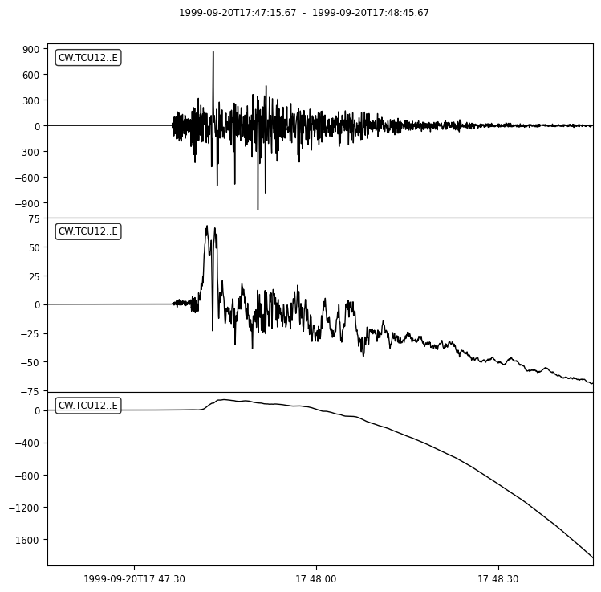

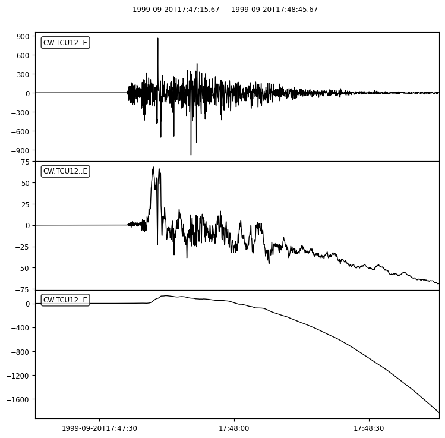

```python
from obspy import Stream

stc_e = Stream(traces=[sta_e[0], stv_e[0], std_e[0]])
stc_e.plot(equal_scale=False)
```

## 3 Koreksi Baseline Sederhana

### 3.1 Mengambil data dari `Stream`

Data waktu dapat diambil dari `Trace.times()` dan data rekaman diambil dari `Trace.data`. `Trace` diambil dengan menggunakan indeks `sta_e[0]`:

```python
times = sta_e[0].times()
sta_e_data = sta_e[0].data
sta_e_data
```

```
array([-0.17962647,  0.        ,  0.05987549, ..., -1.73638916,
       -1.07775879, -0.95800781])
```

Pasangan waktu dan data rekaman dapat kita plot dengan `matplotlib`"

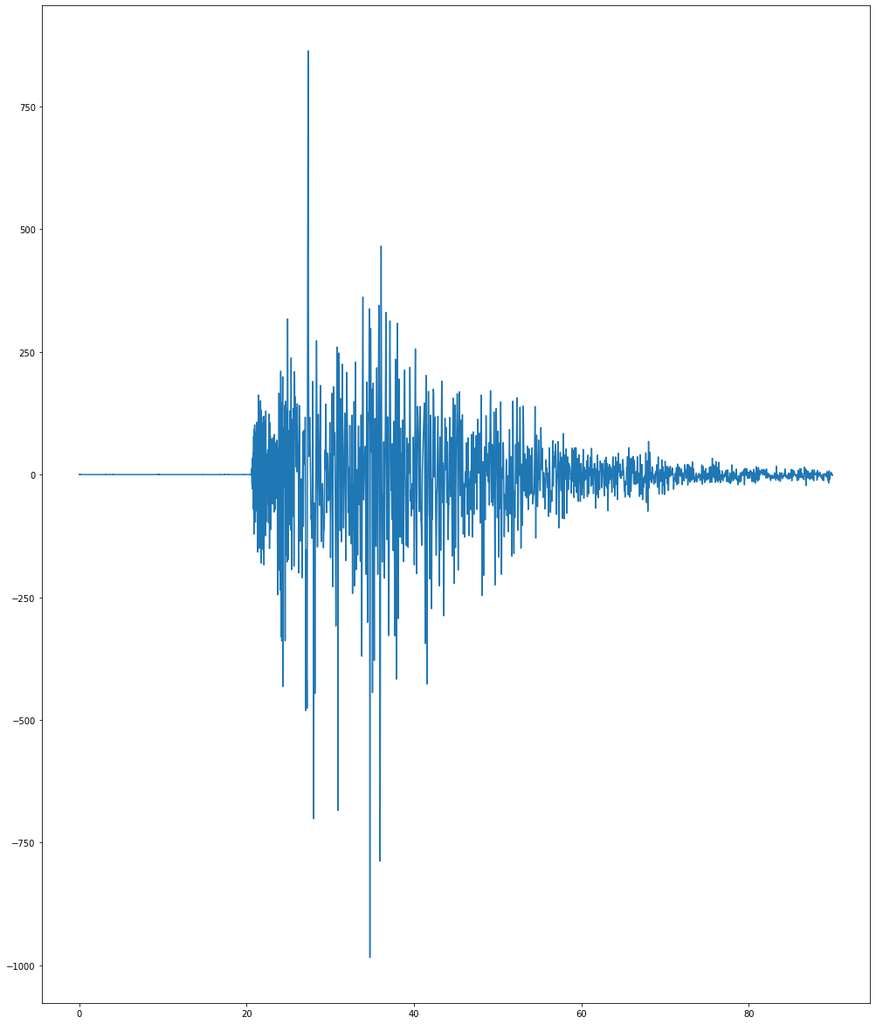

```python
import matplotlib.pyplot as plt

plt.plot(times, sta_e_data)
```

### 3.2 Mengambil data *pre-event*

Data sebelum event akan diambil pada 0-18 sekon, untuk data dalam bentuk `numpy.array` kita dapat memanfaatkan `np.where`. Fungsi ini akan memberikan indeks dimana nilai sesuai dengan kondisi yang kita inginkan:

```python
import numpy as np

pre_event_index=np.where((times>0) & (times<=18))
pre_event_index
```

```
(array([   1,    2,    3, ..., 3598, 3599, 3600]),)
```

selanjutnya kita dapat mengambil data yang kita inginkan (0-18 sekon):

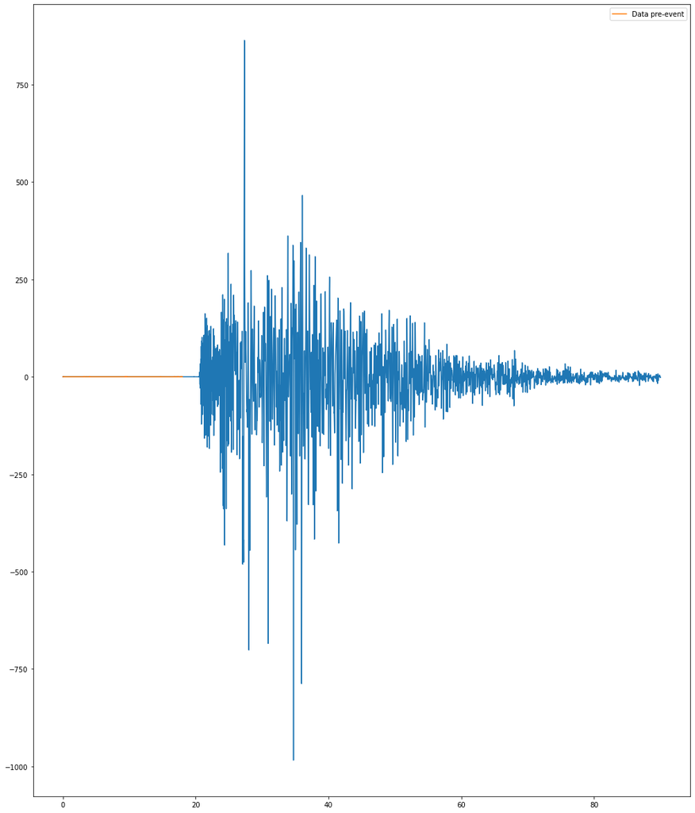

```python
times_preev = times[pre_event_index]
sta_e_data_preev = sta_e_data[pre_event_index]

plt.plot(times, sta_e_data)
plt.plot(times_preev, sta_e_data_preev, label='Data pre-event')
plt.legend()
```

```python
simple_baseline_coeff=sta_e_data.mean()
print(simple_baseline_coeff)
```

```
-0.7634964629307261
```

Koreksi dapat kita lakukan dengan operasi matematika sederhana:

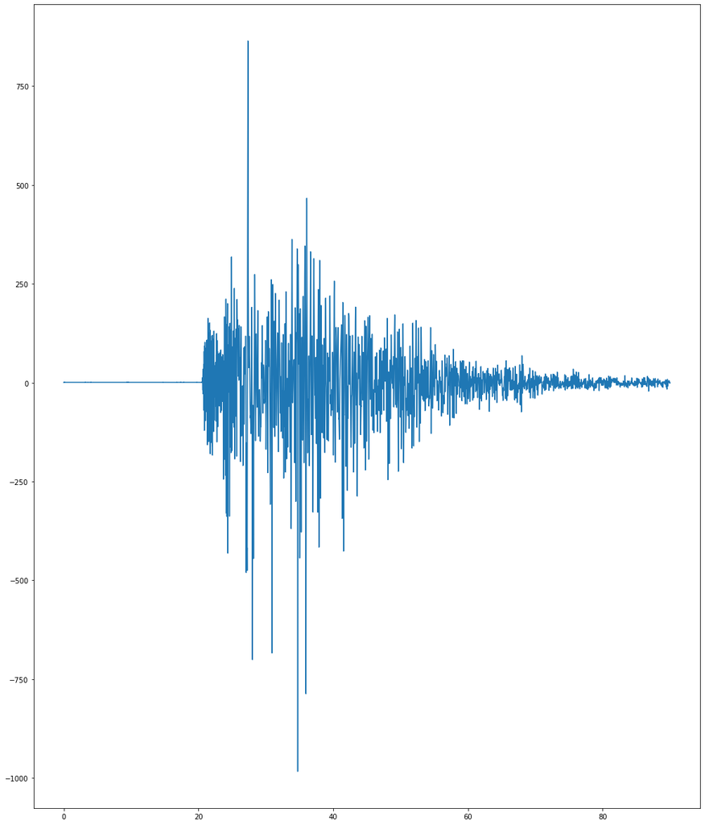

```python
sta_e_data = sta_e_data-simple_baseline_coeff
plt.plot(times, sta_e_data)
```

### 3.4 Melakukan integrasi untuk mendapatkan kecepatan dan *displacement*

Data terlebih dahulu dikonversi ke dalam objek `Stream`:

```python
sta_e_cor_simple = sta_e[0].copy()
sta_e_cor_simple.data = sta_e_data
sta_e_cor_simple.plot()
```

[output not shown]

kemudian mengintegrasikan ke kecepatan:

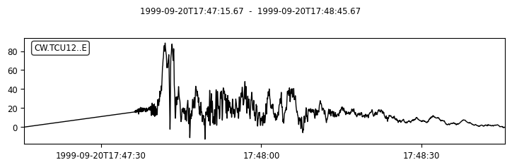

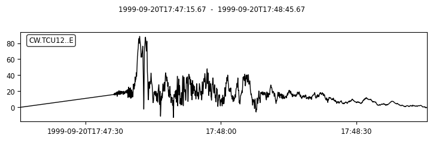

```python
sta_e_cor_simple_vel = sta_e_cor_simple.copy()
sta_e_cor_simple_vel.integrate()

sta_e_cor_simple_vel.plot()
```

dan *displacement*:

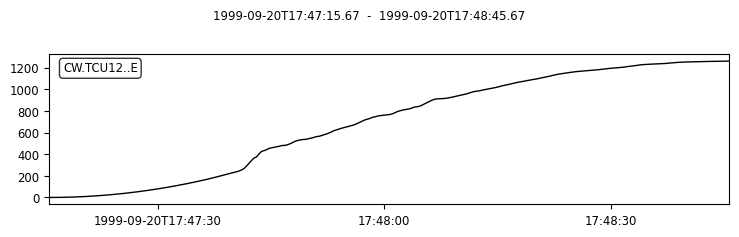

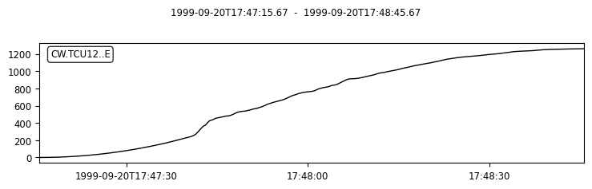

```python
sta_e_cor_simple_disp = sta_e_cor_simple_vel.copy()
sta_e_cor_simple_disp.integrate()

sta_e_cor_simple_disp.plot()
```

## 4 Koreksi Baseline dengan *Fitting* Data *Event*

Pada koreksi ini *fitting* garis akan dilakukan pada data *event*:

### 4.1 Mengambil data

Pengambilan data sama seperti pada proses 3.1 menggunakan bantuan `numpy.where`:

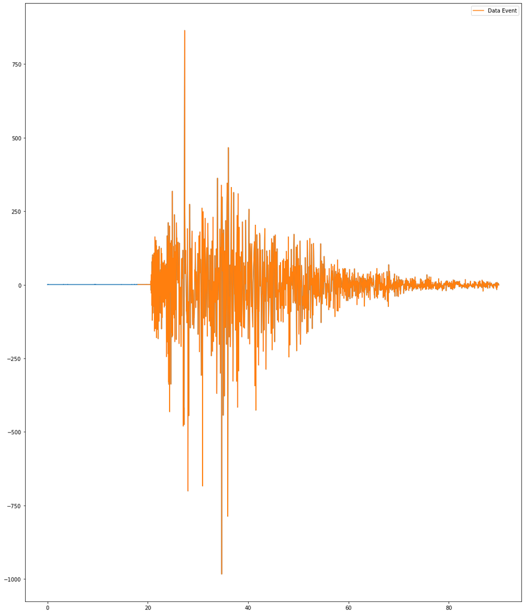

```python
event_index=np.where((times>18))

sta_e_data_event = sta_e_data[event_index]
times_event = times[event_index]

plt.plot(times, sta_e_data)
plt.plot(times_event, sta_e_data_event, label='Data Event')
plt.legend()
```

### 4.2 Kalkulasi parameter *fitting*

Parameter *fitting* dapat dilakukan dengan regresi memanfaatkan `scipy.stats.linregress`:

```python
import scipy

regression = scipy.stats.linregress(times_event, sta_e_data_event)
slope = regression[0]
intercept = regression[1]
print(slope, intercept)
```

```
-0.020495715458913096 0.914237845788737
```

Garis hasil regresi dapat diplot:

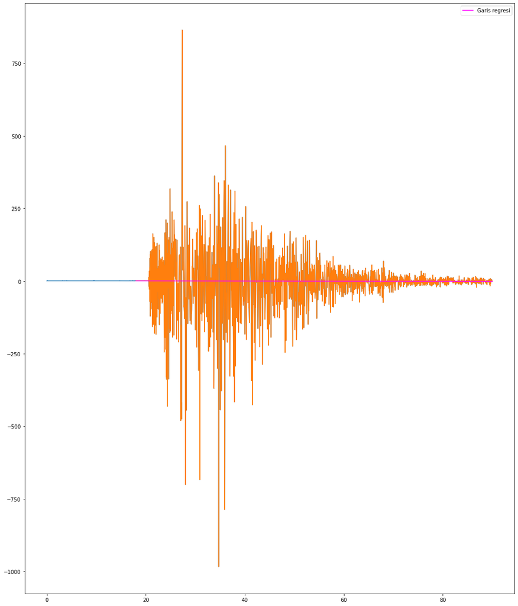

```python
trend_event = times_event*slope + intercept

plt.plot(times, sta_e_data)
plt.plot(times_event, sta_e_data_event)
plt.plot(times_event, trend_event, color='magenta', label="Garis regresi")
plt.legend()
```

### 4.1 Melakukan koreksi

Koreksi dilakukan dengan pengurangan:

```python
sta_e_data_event_cor_fit = sta_e_data_event - trend_event
sta_e_data_event_cor_fit
```

```
array([ 0.098533  ,  0.21838645,  0.15861344, ..., -0.04272111,
        0.61601174,  0.7358652 ])
```

Jika diplot tidak terlalu terlihat perbedaan karena memang mendekati garis lurus di 0:

```
(34.0, 36.0)
```

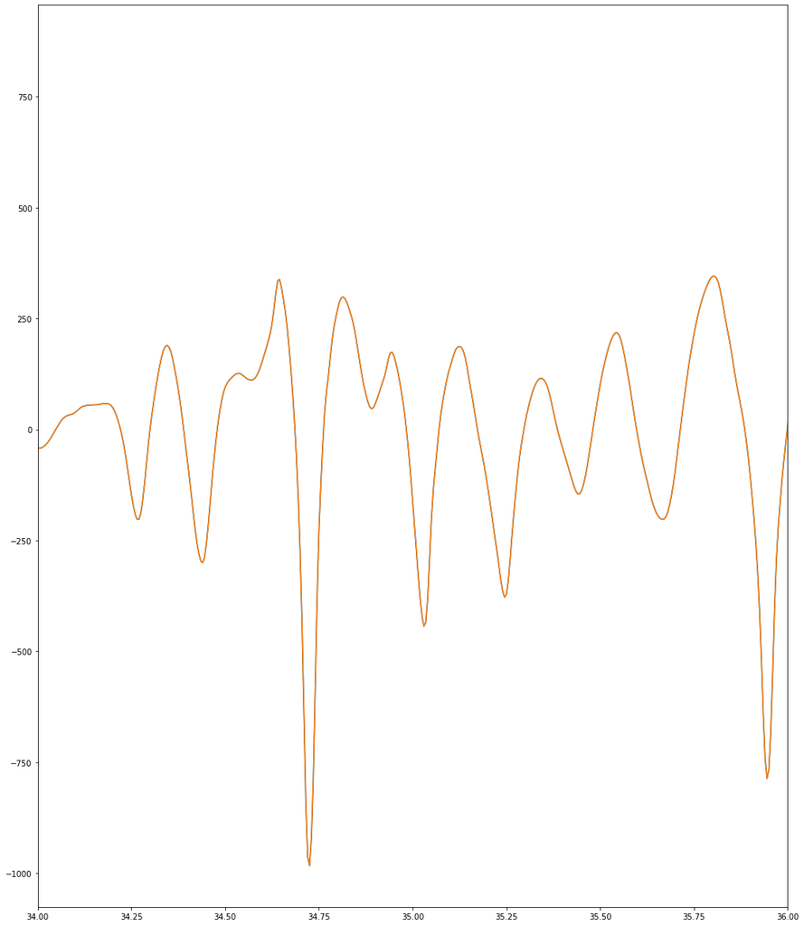

```python
plt.plot(times_event, sta_e_data_event)
plt.plot(times_event, sta_e_data_event_cor_fit)

plt.xlim(34,36)
```

### 4.4 Mengubah data event menjadi data yang sudah terkoreksi

Karena indeks *event* sudah didapatkan maka data terkoreksi bisa dimasukkan ke data:

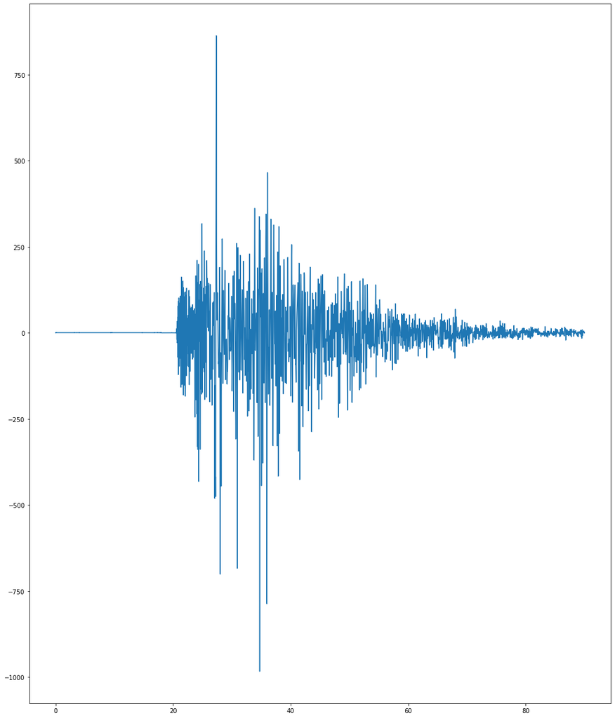

```python
sta_e_data_cor_fit = sta_e_data.copy()
sta_e_data_cor_fit[event_index] = sta_e_data_event_cor_fit

plt.plot(times, sta_e_data_cor_fit)
```

### 4.5 Mengintegrasi untuk mendapatkan kecepatan dan simpangan

Data terlebih dahulu dikonversi ke dalam objek `Stream`:

```python
sta_e_cor_fit = sta_e[0].copy()
sta_e_cor_fit.data = sta_e_data_cor_fit
sta_e_cor_fit.plot()
```

[output not shown]

Integrasi ke kecepatan:

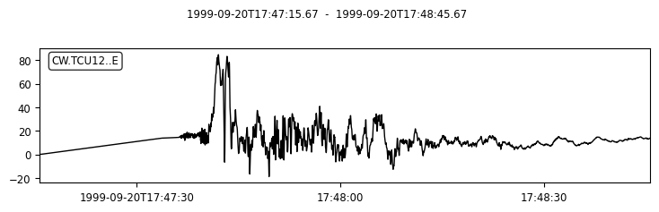

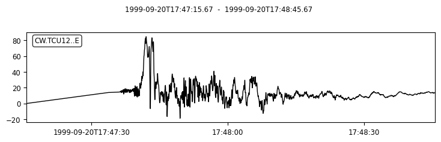

```python
sta_e_cor_fit_vel = sta_e_cor_fit.copy()
sta_e_cor_fit_vel.integrate()

sta_e_cor_fit_vel.plot()
```

Integrasi ke simpangan:

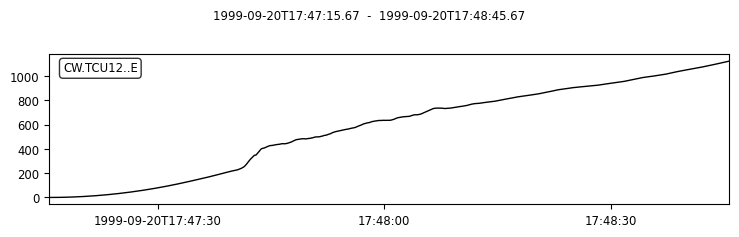

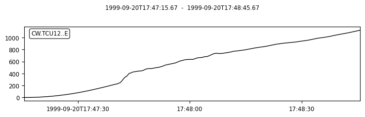

```python
sta_e_cor_fit_disp = sta_e_cor_fit_vel.copy()
sta_e_cor_fit_disp.integrate()

sta_e_cor_fit_disp.plot()
```

## 5 Mengaplikasikan Filter Akausal

Langkah selanjutnya setelah melakukan koreksi pada langkah (4) berdasarkan referensi maka kita dapat melakukan filter *highpass* Butterworth orde 2 dengan frekuensi 0.05 akausal dengan bantuan `obspy`.

### 5.1 Konversi data `numpy.array` ke dalam objek `Stream`

Agar data dapat diolah menggunakan `obspy` maka terlebih dahulu kita buat `Trace` dengan data yang telah kita olah pada tahap sebelumnya. Proses diawali dengan menyalin(*copy*) data asli kemudian mengubah isi data menjadi data yang sudah dikoreksi:

```python
sta_e_cor_fit = sta_e[0].copy()
sta_e_cor_fit.data = sta_e_data_cor_fit
sta_e_cor_fit.plot()
```

[output not shown]

### 5.2 Melakukan *filtering*

Selanjutnya melakukan *filtering*

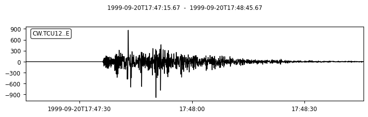

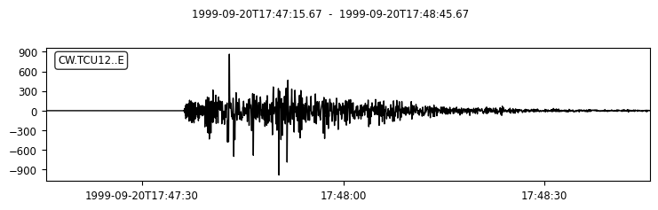

```python
f=0.05
zerophase=True #akausal
corner=2
sta_e_cor_fit_filt1 = sta_e_cor_fit.copy()
sta_e_cor_fit_filt1.filter('highpass', freq=f, zerophase=zerophase, corners=corner)
sta_e_cor_fit_filt1.plot()
```

### 5.3 Melakukan integrasi untuk mendapatkan kecepatahan getaran tanah

Setelah *filtering* selanjutnya dilakukan integrasi untuk mendapatkan gerakan tanah dengan proses yang sama seperti sebelumnya:

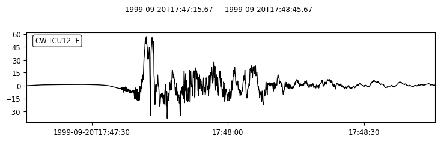

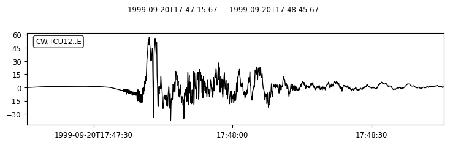

```python
sta_e_cor_fit_filt1_vel = sta_e_cor_fit_filt1.copy()
sta_e_cor_fit_filt1_vel.integrate()

sta_e_cor_fit_filt1_vel.plot()
```

Dari hasil integrasi di atas terdapat data transien sebelum *event* yang dapat mengurangi nilai puncak